# 土地利用、生物多样性和环境公平

康杰锋

## 引言

本文主要是关于土地利用、社会经济因子和生物多样性的关系，要讨论的主要问题是环境公平。

在先行研究中，除了土地利用等景观要素与生物多样性的关系，还有很多研究聚焦社会经济要素和生物多样性的关系。后者的结果表明，在很多城市中，存在”luxury effect”，其实就是环境不平等在生物多样性方面的体现：收入越高的居住区，往往生物多样性也越高。但是这个结果可能因城市设计、人们的居住选择、文化而有所不同。本文综合了**景观要素和社会经济要素，探究城市生物多样性的成因或后果。**

本研究的响应变量为各种生物多样性指标，包括：乔木的abundance、richness、Shannon指数，灌木的abundance、richness、Shannon指数，乔木灌木合起来的richness。

解释变量包括：（1）景观变量，为样地中各类土地覆盖的百分比，包括居住用地、交通用地、农业用地、公园、公共机构等等；（2）社会变量，为人口结构，包括0-14岁、15-64岁、65岁以上、75岁以上、85岁以上人口占比；（3）经济变量，采用了地价。

我先用皮尔森相关简单看了各个响应变量和各解释变量的关系，然后对每一个相应变量～解释变量组都构建了模型，筛选出最佳回归模型。

## 相关分析

从下面的相关图可以看出，各个解释变量对各响应变量的效应比较一致。例如，居住用地比例对灌木richness、Shannon以及乔灌木richness都是正效应，也就是说在不考虑其他解释变量的情况下，样地中居住用地比例越大，灌木richness、Shannon以及乔灌木总richness就越高。而park主要对乔木abundance和灌木abundance起显著正效应，这也很容易解释，因为公园里种的植物通常比较多，所以abundance高，但是种类不一定多。pop15_64_prop则主要对乔木各项指标起负效应，也就是说15-64岁人口比例高的地方，乔木的多样性比较低。我们关注的一个重点，小孩和老人的情况则是：0-14岁人口比例高的地方，乔灌木总richness比较高，这是件好事，意味着小朋友们能够接触到的植物种类较多，而高龄者相关的几个解释变量（65岁以上/75岁以上/85岁以上人口占比）和多样性的其中几个指标都是正相关，这两点说明京都市的生物多样性环境对小孩和老人都比较友好。至于地价，出乎意料的是，虽然不显著，但是表现出了负效应，也就是说是一种反luxury effect：地价高的地方反而生物多样性低。

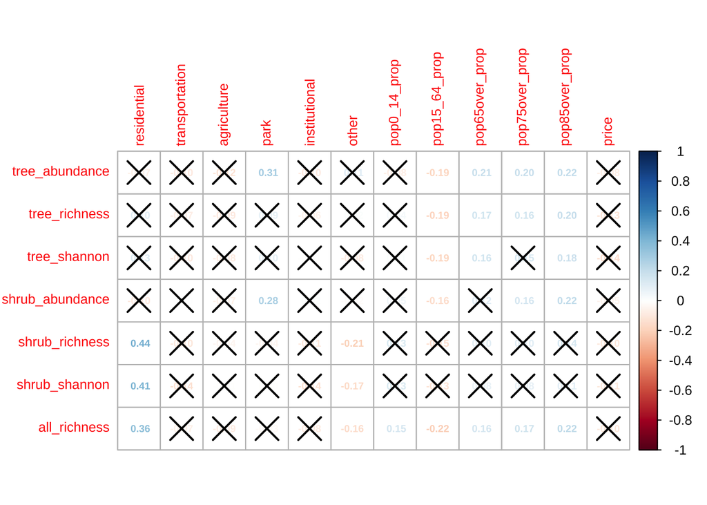

```r
GetCorrplot(
  st_drop_geometry(qua_bd_var)[bd_index],
  st_drop_geometry(qua_bd_var)[c(land_cover_var, pop_var, "price")] %>%
    # Bug: Revemo multi-family-resi for now.
    select(-multi_family_residential)
)
```

当然，也可以直观地查看这些变量之间的关系：

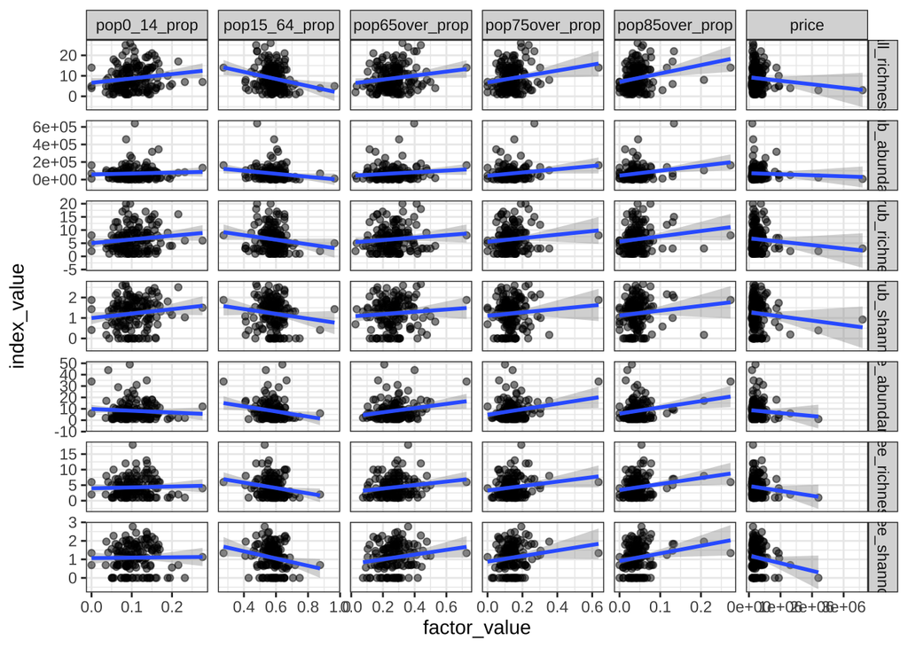

```r
qua_bd_var %>%
  select(qua_id, all_of(bd_index), price, all_of(pop_var)) %>%
  pivot_longer(cols = c("price", pop_var),
               names_to = "factor", values_to = "factor_value") %>%
  pivot_longer(cols = bd_index,
               names_to = "index", values_to = "index_value") %>%
  ggplot(aes(factor_value, index_value)) +
  geom_point(alpha = 0.5) +
  geom_smooth(method = "lm", formula = "y ~ x") +
  facet_grid(index ~ factor, scales = "free") +
  theme_bw()
```

## 回归模型

当然，相关分析仅考虑了一对变量之间的关系，而没有考虑其他变量的影响，因此我们还需要做回归分析。

回归分析的首要问题是如何选入变量。在本研究中，我们有3组解释变量：景观，人口，经济。我们通过全子集方法来选入变量：对于给定的几个解释变量，检测所有模型，例如对于3个解释变量，我们可以构建以下几种可能模型形式：

只包含一个解释变量：y ~ x1；y ~ x2；y ~ x3；

包含两个解释变量：y ~ x1 + x2；y ~ x1 + x3；y ~ x2 + x3；

包含三个解释变量：y ~ x1 + x2 + x3。

对于每个模型，有一个AIC值，AIC值和模型解释变量数量以及模型的拟合程度有关。简单来说，解释变量越少，拟合程度越高，则AIC越小。所以我们通常认为AIC越小，模型越好。但是如果最终选出的”最佳模型”只有一个解释变量，对于我们要探究的问题可能又没多大意义，因此也会折中一下，选择AIC较小，但是又包含感兴趣的解释变量的模型。

那么，我就对每个响应变量（如乔木的richness）和以下几组解释变量建立配对：

乔木的richness ～ 景观变量组；

乔木的richness ～ 人口变量组；

乔木的richness ～ 地价；

乔木的richness ～ 景观变量 + 地价；

乔木的richness ～ 人口变量 + 地价；

乔木的richness ～ 景观变量 + 人口变量 + 地价。

对于每个配对，都采用了上面说的全子集回归方法，筛选出AIC最小的5个模型。例如，对于”乔木的richness ～ 景观变量组”这个配对，最好的5个模型是：

```r
reg_res$tree_richness$land_cover
```

```
##    AICc NumVars                                                        Terms
## 1 338.3       2                                             residential park
## 2 338.7       1                                     multi_family_residential
## 3 339.1       3                                       residential park other
## 4 340.6       4                           residential agriculture park other
## 5 342.7       5  residential multi_family_residential agriculture park other
```

而对于”乔木的richness ～ 人口变量组”这个配对，最佳模型是：

```r
reg_res$tree_richness$pop
```

```
##    AICc NumVars
## 1 333.3       2
## 2 333.9       1
## 3 334.1       3
## 4 334.4       4
## 5 336.4       5
##                                                                      Terms
## 1                                              pop0_14_prop pop85over_prop
## 2                                                           pop85over_prop
## 3                               pop0_14_prop pop65over_prop pop85over_prop
## 4                pop0_14_prop pop65over_prop pop75over_prop pop85over_prop
## 5  pop0_14_prop pop15_64_prop pop65over_prop pop75over_prop pop85over_prop
```

```r
reg_res
```

[output not shown]

[output cut: 573 more lines]

```
## 5  pop0_14_prop pop15_64_prop pop65over_prop pop75over_prop pop85over_prop price
##
## $all_richness$`land_cover + pop + price`
##    AICc NumVars
## 1 577.7       3
## 2 578.2       4
## 3 578.4       5
## 4 579.4       6
## 5 580.6       7
##                                                                                               Terms
## 1                                                           residential pop0_14_prop pop85over_prop
## 2                                               residential agriculture pop0_14_prop pop85over_prop
## 3                      residential multi_family_residential agriculture pop0_14_prop pop85over_prop
## 4                residential multi_family_residential agriculture pop0_14_prop pop85over_prop price
## 5  residential multi_family_residential agriculture pop0_14_prop pop15_64_prop pop85over_prop price
```

## 附录

采样地点分布：

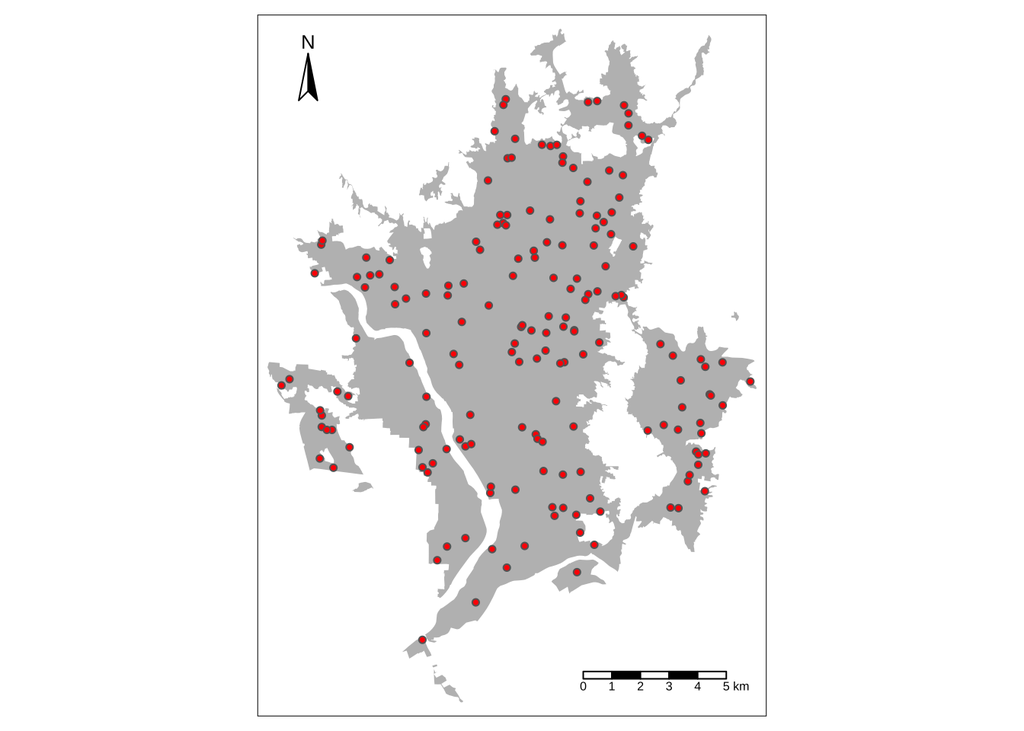

```r
tm_shape(kyo_built) +
  tm_fill(col = "grey") +
  tm_shape(qua_position, bbox = map_bbox) +
  tm_symbols(size = 0.1, col = "red") +
  tm_compass(position = c("left", "top")) +
  tm_scale_bar()
```

人口：展示0-14岁和85岁以上人口数量（不是人口占比）分布：

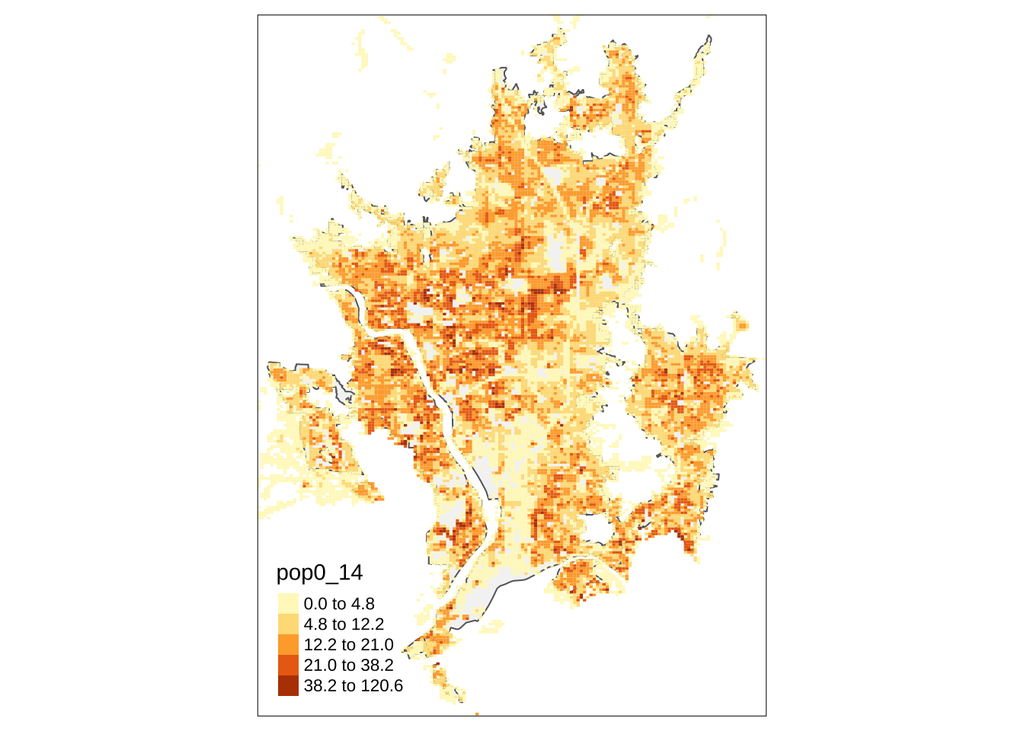

```r
tm_shape(kyo_built) +
  tm_polygons(alpha = 0.3) +
  tm_shape(kyo_pop) +
  tm_polygons(col = "pop0_14", border.alpha = 0, style = "kmeans")
```

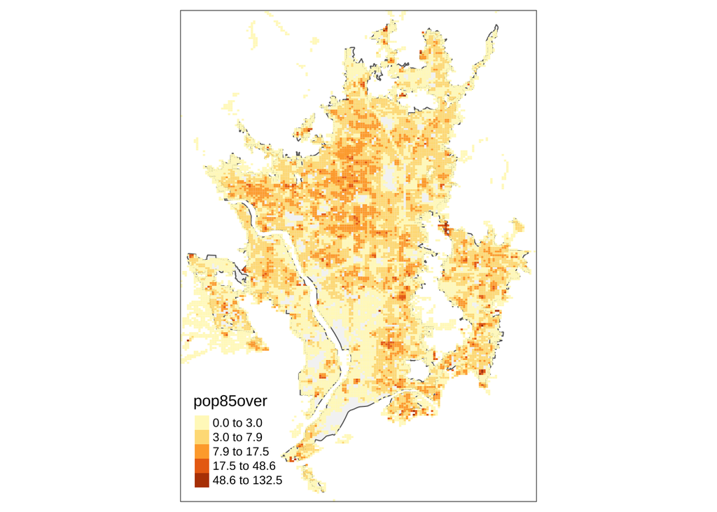

```r
tm_shape(kyo_built) +
  tm_polygons(alpha = 0.3) +
  tm_shape(kyo_pop) +
  tm_polygons(col = "pop85over", border.alpha = 0, style = "kmeans")
```

地价的分布：

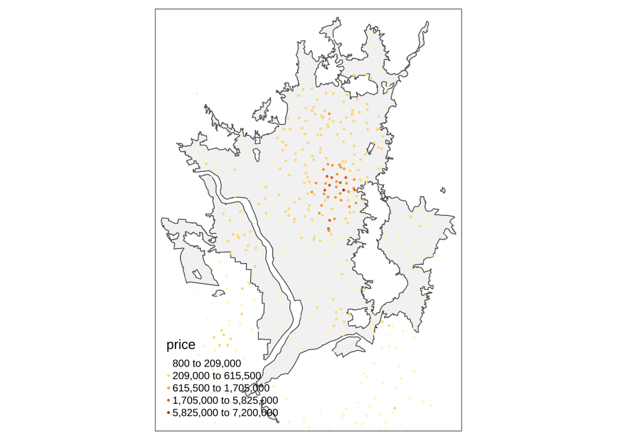

```r
tm_shape(kyo_built) +
  tm_polygons(alpha = 0.3) +
  tm_shape(land_price) +
  tm_dots(col = "price", border.alpha = 0, style = "kmeans")
```